# Graduation Project - Technical Report

as a partial fulfillment of the degree of Bachelor of Science in Business Administration* Efficiency Measurement of Product Performance PCA-DEA A Combined Model Approach for Dimension Reduction Farah Aboucha Tunis Business School University of Tunis

### I- Introduction:

The motivation behind combining DEA and PCA is to gain a deeper understanding of efficiency scores obtained while reducing data dimensiality. This approach involves several steps that will be captured in this report. First, PCA was conducted to reduce the dimensionality of the chosen input and output variables.  
Second, DEA was applied into 4 different models. Finally, peers analysis and excess were conducted on the chosen model

### II- Data understanding and modeling:

#### 2- Output:

- Output 1: Order count per product group,
- Output 2: gross profit per product group,
- Output 3: Net promoter score per product group.

#### 3- Model:

Performing an input-oriented model is particularly important when the goal is to minimize the inputs.

### III- Data Cleaning and Pre-processing:

In this study, the data consists of weekly observations spanning from week 30 of 2022 to week 13 of 2023. This period corresponds approximately to July 2022 and March 2023.

#### 1- Fill the missing values:

It was identified that 5 datasets contained missing values. To address this issue, the interpolation technique was employed in Python. This technique allows for the estimation of missing values by leveraging the available data from similar time periods.  
The conversion into numeric type was performed to ensure that the data was in a suitable format for further analysis. The filled data, now in numeric format, was saved and prepared for the subsequent steps of the analysis.

##### Input2: Shipping cost

```python
import pandas as pd

df = pd.read_excel('/Users/farahaboucha/Desktop/Graduation Project/Shipping List Unit Price per product group.xlsx')
df = df.fillna(method='ffill').fillna(method='bfill')

df.iloc[:, 1:] = df.iloc[:, 1:].apply(pd.to_numeric)
df = df.interpolate(method='linear')
df.to_excel('/Users/farahaboucha/Desktop/Graduation Project/Filled Input2.xlsx', index=False)
```

##### Input4: Product cost

```python
import pandas as pd

df = pd.read_excel('/Users/farahaboucha/Desktop/Graduation Project/Product cost by product group.xlsx')
df = df.fillna(method='ffill').fillna(method='bfill')

df.iloc[:, 1:] = df.iloc[:, 1:].apply(pd.to_numeric)
df = df.interpolate(method='linear')
df.to_excel('/Users/farahaboucha/Desktop/Graduation Project/Filled Input4.xlsx', index=False)
```

##### Output 1: Order count

```python
import pandas as pd

count = pd.read_excel('/Users/farahaboucha/Desktop/Graduation Project/Order Count per Product group.xlsx')
count = count.fillna(method='ffill').fillna(method='bfill')

count.iloc[:, 1:] = count.iloc[:, 1:].apply(pd.to_numeric)
count = count.interpolate(method='linear')
count.to_excel('/Users/farahaboucha/Desktop/Graduation Project/Filled Output1.xlsx', index=False)
```

##### Output 2: Gross profit

```python
import pandas as pd

profit = pd.read_excel('/Users/farahaboucha/Desktop/Graduation Project/Gross profit per product group.xlsx')
profit = profit.fillna(method='ffill').fillna(method='bfill')

profit.iloc[:, 1:] = profit.iloc[:, 1:].apply(pd.to_numeric)
profit = profit.interpolate(method='linear')
profit.to_excel('/Users/farahaboucha/Desktop/Graduation Project/Filled Output2.xlsx', index=False)
```

##### Output 3: Net promoter score

```python
import pandas as pd

NPS = pd.read_excel('/Users/farahaboucha/Desktop/Graduation Project/NPS by Product Group.xlsx')
NPS = NPS.fillna(method='ffill').fillna(method='bfill')

NPS.iloc[:, 1:] = NPS.iloc[:, 1:].apply(pd.to_numeric)
NPS = NPS.interpolate(method='linear')
NPS.to_excel('/Users/farahaboucha/Desktop/Graduation Project/Filled Output3.xlsx', index=False)
```

#### 2- Summarize the time period:

The filled datasets along with Input 3, will be averaged. This approach ensures a more stable and representative measure of these variables.  
For Input 1, the order rejections will be aggregated over the time periods. Similarly, the Net Promoter score will remain the same as we have decided to include only one month for data unavailability.

##### Input1: Counted rejections

```python
df = pd.read_excel('/Users/farahaboucha/Desktop/Graduation Project/Order rejections per product group.xlsx')
Counted_Rejections = df['Product ID'].value_counts()

Input1 = pd.DataFrame({'Product ID': Counted_Rejections.index, 'Counted Rejections': Counted_Rejections.values})
Input1.to_excel('/Users/farahaboucha/Desktop/Graduation Project/Input1.xlsx', engine='openpyxl', index=False)

print(Input1.head())
```

```
##    Product ID  Counted Rejections
## 0         1.0                1870
## 1         4.0                 360
## 2         2.0                 318
## 3         5.0                 158
## 4         3.0                 155
```

##### Input2: Average shipping cost

```python
df = pd.read_excel('/Users/farahaboucha/Desktop/Graduation Project/Filled Input2.xlsx')
df['Average Shipping Cost'] = df.iloc[:, 1:].mean(axis=1)

Input2 = df[['Product ID', 'Average Shipping Cost']].copy()
Input2.to_excel('/Users/farahaboucha/Desktop/Graduation Project/Input2.xlsx', index=False)
print(Input2.head())
```

```
##    Product ID  Average Shipping Cost
## 0           1               4.068735
## 1           2               3.217055
## 2           3               1.762321
## 3           4               2.024766
## 4           5               2.036675
```

##### Input3: Average Items wih complaints

```python
df = pd.read_excel('/Users/farahaboucha/Desktop/Graduation Project/Complaint Rate by Product Group Weekly.xlsx')
df = df.loc[:, ~df.columns.str.contains('Complaint Rate|Complaint Action Amount|Complaint Items VGP')]
df_cleaned = df.dropna(subset=['Items with Complaint'])

Input3 = df_cleaned.groupby('Product ID')['Items with Complaint'].mean().reset_index()
Input3.to_excel('/Users/farahaboucha/Desktop/Graduation Project/Input3.xlsx', index=False)

print(Input3.head())
```

```
##    Product ID  Items with Complaint
## 0         1.0                 160.0
## 1         2.0                  80.0
## 2         3.0                  50.0
## 3         4.0                  49.0
## 4         5.0                  42.0
```

##### Input4: Average product cost

```python
df = pd.read_excel('/Users/farahaboucha/Desktop/Graduation Project/Filled Input4.xlsx')
df['Average product cost'] = df.iloc[:, 1:].mean(axis=1)

Input4 = df[['Product ID', 'Average product cost']].copy()
Input4.to_excel('/Users/farahaboucha/Desktop/Graduation Project/Input4.xlsx', index=False)
print(Input4.head())
```

```
##    Product ID  Average product cost
## 0           1              6.315177
## 1           2             35.384452
## 2           3              7.708251
## 3           4             20.678609
## 4           5             10.616473
```

##### Output1: Average order count

```python
df = pd.read_excel('/Users/farahaboucha/Desktop/Graduation Project/Filled Output1.xlsx')
df['Average Order Count'] = round(df.iloc[:, 1:].mean(axis=1), 0)

Output1 = df[['Product ID', 'Average Order Count']].copy()
Output1.to_excel('/Users/farahaboucha/Desktop/Graduation Project/Output1.xlsx', index=False)

print(Output1.head())
```

```
##    Product ID  Average Order Count
## 0           1               1054.0
## 1           2               1389.0
## 2           3               1031.0
## 3           4                765.0
## 4           5                437.0
```

##### Output2: Average gross profit

```python
df = pd.read_excel('/Users/farahaboucha/Desktop/Graduation Project/Filled Output2.xlsx')
df['Average gross profit'] = round(df.iloc[:, 1:].mean(axis=1), 0)

Output2 = df[['Product ID', 'Average gross profit']].copy()
Output2.to_excel('/Users/farahaboucha/Desktop/Graduation Project/Output2.xlsx', index=False)

print(Output2.head())
```

```
##    Product ID  Average gross profit
## 0           1                   2.0
## 1           2                  26.0
## 2           3                  14.0
## 3           4                  15.0
## 4           5                   7.0
```

##### Output3: Net promoter score

```python
NPS = pd.read_excel('/Users/farahaboucha/Desktop/Graduation Project/Filled Output3.xlsx')
NPS['Monthly NPS'] = round(NPS.iloc[:, 1])

Output3 = NPS[['Product ID', 'Monthly NPS']].copy()
Output3.to_excel('/Users/farahaboucha/Desktop/Graduation Project/Output3.xlsx', index=False)

print(Output3.head())
```

```
##    Product ID  Monthly NPS
## 0           1         68.0
## 1           2         72.0
## 2           3         66.0
## 3           4         76.0
## 4           5         85.0
```

#### 3- Data normalization:

Once all the datasets are prepared, we proceed to the normalization step. In order to perform PCA and DEA, the input and output data for each DMU must be stored in a merged file.

##### Merging the variables

```python
Input1 = pd.read_excel('/Users/farahaboucha/Desktop/Graduation Project/Input1.xlsx')
Input2 = pd.read_excel('/Users/farahaboucha/Desktop/Graduation Project/Input2.xlsx')
Input3 = pd.read_excel('/Users/farahaboucha/Desktop/Graduation Project/Input3.xlsx')
Input4 = pd.read_excel('/Users/farahaboucha/Desktop/Graduation Project/Input4.xlsx')
Output1 = pd.read_excel('/Users/farahaboucha/Desktop/Graduation Project/Output1.xlsx')
Output2 = pd.read_excel('/Users/farahaboucha/Desktop/Graduation Project/Output2.xlsx')
Output3 = pd.read_excel('/Users/farahaboucha/Desktop/Graduation Project/Output3.xlsx')

Dataset = pd.merge(Input1, Input2, on='Product ID')
Dataset = pd.merge(Dataset, Input3, on='Product ID')
Dataset = pd.merge(Dataset, Input4, on='Product ID')
Dataset = pd.merge(Dataset, Output1, on='Product ID')
Dataset = pd.merge(Dataset, Output2, on='Product ID')
Dataset = pd.merge(Dataset, Output3, on='Product ID')
Dataset.to_excel('/Users/farahaboucha/Desktop/Graduation Project/Dataset.xlsx', index=False)
print(Dataset.head())
```

```
##    Product ID  Counted Rejections  ...  Average gross profit  Monthly NPS
## 0           1                1870  ...                     2           68
## 1           4                 360  ...                    15           76
## 2           2                 318  ...                    26           72
## 3           5                 158  ...                     7           85
## 4           3                 155  ...                    14           66
##
## [5 rows x 8 columns]
```

##### Normalization

```python
from sklearn.preprocessing import MinMaxScaler

dataset = pd.read_excel('/Users/farahaboucha/Desktop/Graduation Project/Dataset.xlsx')
scaler = MinMaxScaler()
columns_to_normalize = ['Counted Rejections', 'Average Shipping Cost', 'Items with Complaint', 'Average product cost', 'Average Order Count', 'Average gross profit', 'Monthly NPS']
normalized_dataset = scaler.fit_transform(dataset[columns_to_normalize])

dataset[columns_to_normalize] = normalized_dataset

dataset = dataset.sort_values(by=dataset.columns[0])
dataset.to_excel('/Users/farahaboucha/Desktop/Graduation Project/Normalized Dataset.xlsx', index=False)
```

### IV- PCA Application:

#### 1- Optimal Principal Components:

##### Input and Output Matrix of data creation:

```r
data <- read_excel("/Users/farahaboucha/Desktop/Graduation Project/Normalized Dataset.xlsx")

input.data.matrix <- matrix(nrow = nrow(data), ncol = 4)
colnames(input.data.matrix) <- c("Counted Rejections", "Average Shipping Cost", "Items with Complaint", "Average product cost")
rownames(input.data.matrix) <- paste(1:nrow(data), sep = "")

input.data.matrix[, "Counted Rejections"] <- data$`Counted Rejections`
input.data.matrix[, "Average Shipping Cost"] <- data$`Average Shipping Cost`
input.data.matrix[, "Items with Complaint"] <- data$`Items with Complaint`
input.data.matrix[, "Average product cost"] <- data$`Average product cost`

input.data.matrix <- apply(input.data.matrix, 2, as.numeric)
head(input.data.matrix)
```

```
##      Counted Rejections Average Shipping Cost Items with Complaint
## [1,]         1.00000000             0.6181396            1.0000000
## [2,]         0.16960942             0.4752585            0.4968553
## [3,]         0.08239700             0.2312064            0.3081761
## [4,]         0.19208133             0.2752352            0.3018868
## [5,]         0.08400214             0.2772332            0.2578616
## [6,]         0.02140182             0.4222182            0.2075472
##      Average product cost
## [1,]           0.02478593
## [2,]           0.16322217
## [3,]           0.03142015
## [4,]           0.09318872
## [5,]           0.04526994
## [6,]           0.02268905
```

```r
data <- read_excel("/Users/farahaboucha/Desktop/Graduation Project/Normalized Dataset.xlsx")

output.data.matrix <- matrix(nrow = nrow(data), ncol = 3)
colnames(output.data.matrix) <- c( "Average Order Count", "Average gross profit", "Monthly NPS")
rownames(output.data.matrix) <- paste(1:nrow(data), sep = "")

output.data.matrix[, "Average Order Count"] <- data$`Average Order Count`
output.data.matrix[, "Average gross profit"] <- data$`Average gross profit`
output.data.matrix[, "Monthly NPS"] <- data$`Average gross profit`

output.data.matrix <- apply(output.data.matrix, 2, as.numeric)
head(output.data.matrix)
```

```
##      Average Order Count Average gross profit Monthly NPS
## [1,]           0.7588193           0.03040541  0.03040541
## [2,]           1.0000000           0.11148649  0.11148649
## [3,]           0.7422606           0.07094595  0.07094595
## [4,]           0.5507559           0.07432432  0.07432432
## [5,]           0.3146148           0.04729730  0.04729730
## [6,]           0.1929446           0.05405405  0.05405405
```

##### Summary of PCA application:

The summary of the PCA analysis provide information about the importance of each principal component (PC) and the proportion of variance explained by each component.

```r
pca.output <- prcomp(output.data.matrix, scale = TRUE)
summary(pca.output)
```

```
## Importance of components:
##                           PC1    PC2       PC3
## Standard deviation     1.4193 0.9928 1.301e-16
## Proportion of Variance 0.6714 0.3286 0.000e+00
## Cumulative Proportion  0.6714 1.0000 1.000e+00
```

```r
pca.input <- prcomp(input.data.matrix, scale = TRUE)
summary(pca.input)
```

```
## Importance of components:
##                           PC1    PC2    PC3     PC4
## Standard deviation     1.4122 1.0096 0.9489 0.29299
## Proportion of Variance 0.4986 0.2548 0.2251 0.02146
## Cumulative Proportion  0.4986 0.7534 0.9785 1.00000
```

##### Scree Plot:

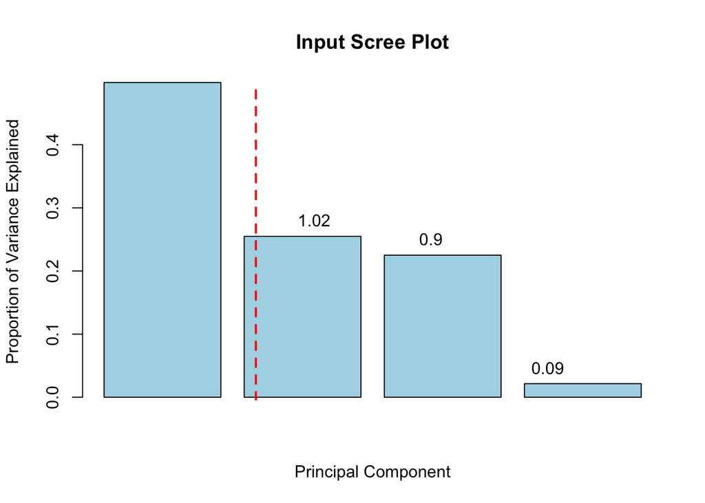

```r
variance_prop <- pca.input$sdev^2 / sum(pca.input$sdev^2)
eigenvalues <- pca.input$sdev^2

barplot(variance_prop, xlab = "Principal Component", ylab = "Proportion of Variance Explained",
        main = "Input Scree Plot", col = "lightblue")
text(x = 1:length(eigenvalues), y = variance_prop, labels = round(eigenvalues, 2), pos = 3)

elbow_point <- 0
for (i in 2:length(eigenvalues)) {
  if (variance_prop[i] - variance_prop[i-1] < 0.05) {
    elbow_point <- i - 1
    break
  }
}
abline(v = elbow_point + 0.5, col = "red", lwd = 2, lty = 2)
```

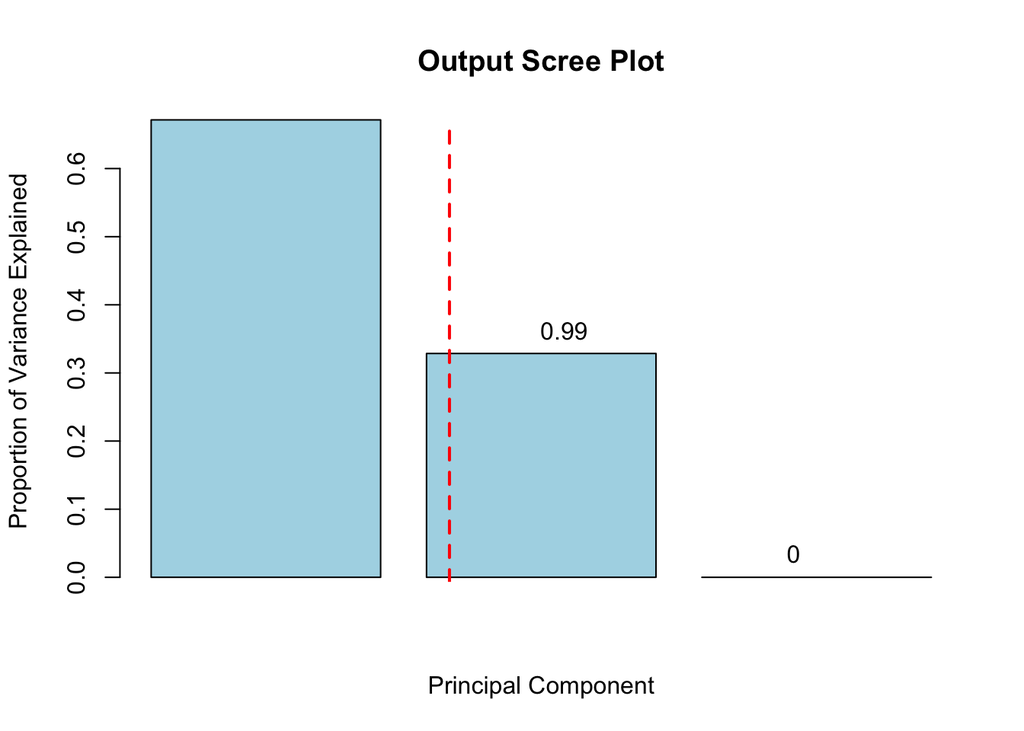

```r
variance_prop <- pca.output$sdev^2 / sum(pca.output$sdev^2)
eigenvalues <- pca.output$sdev^2

barplot(variance_prop, xlab = "Principal Component", ylab = "Proportion of Variance Explained",
        main = "Output Scree Plot", col = "lightblue")
text(x = 1:length(eigenvalues), y = variance_prop, labels = round(eigenvalues, 2), pos = 3)

elbow_point <- 0
for (i in 2:length(eigenvalues)) {
  if (variance_prop[i] - variance_prop[i-1] < 0.05) {
    elbow_point <- i - 1
    break
  }
}
abline(v = elbow_point + 0.5, col = "red", lwd = 2, lty = 2)
```

#### 2- PCA Visualization

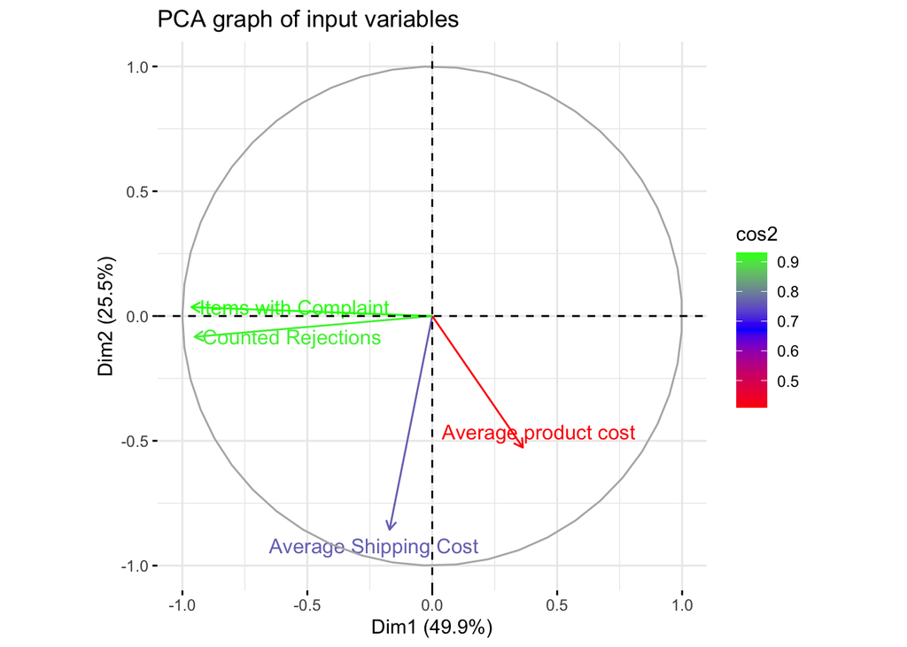

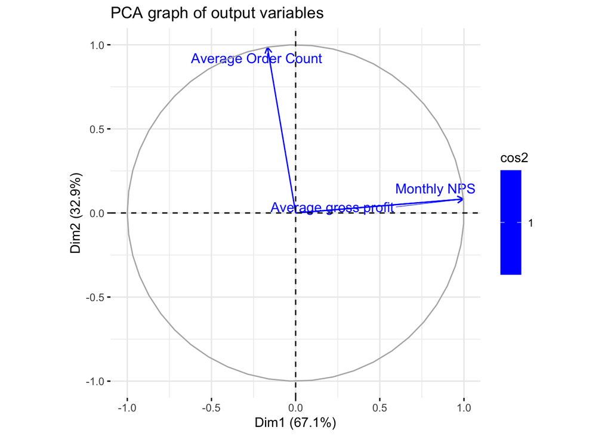

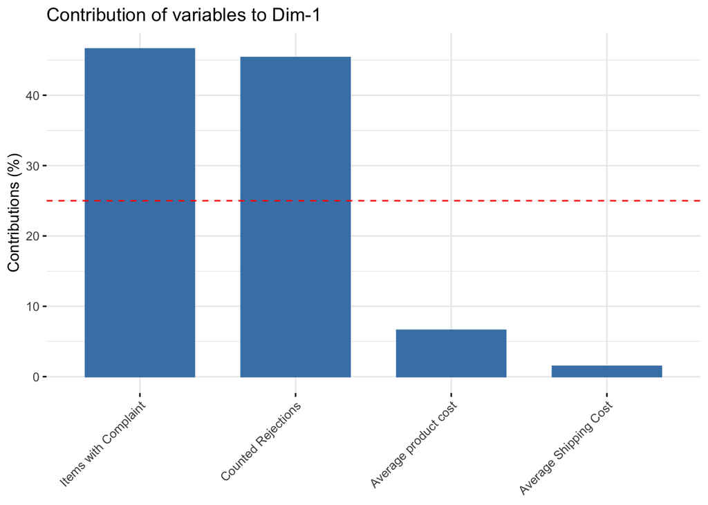

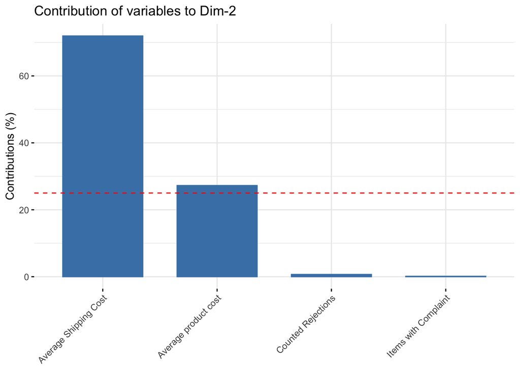

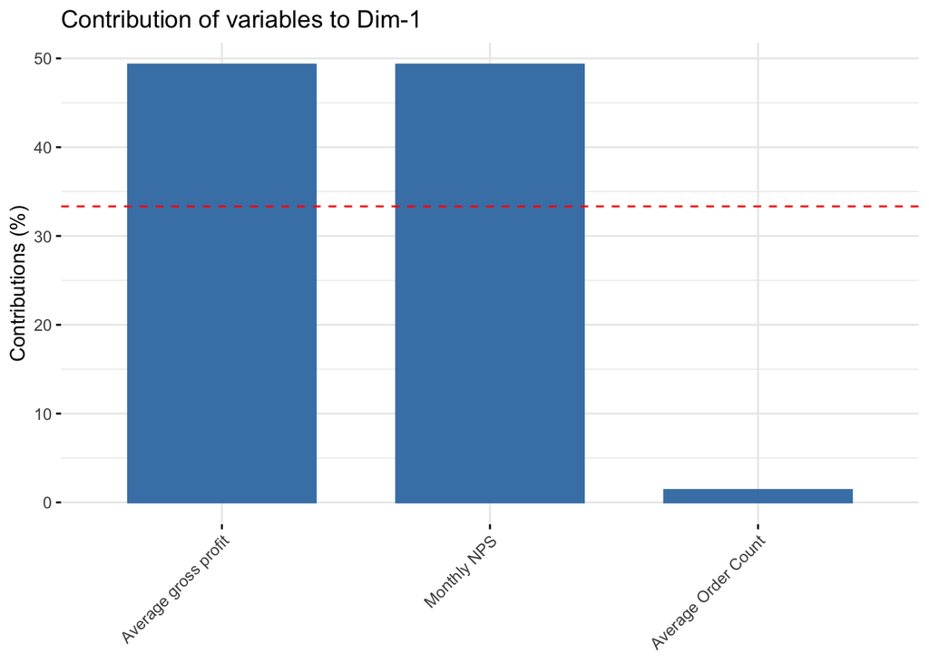

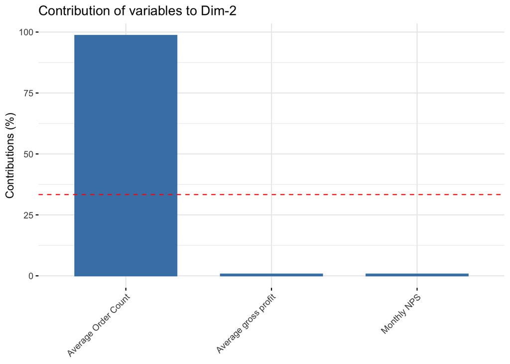

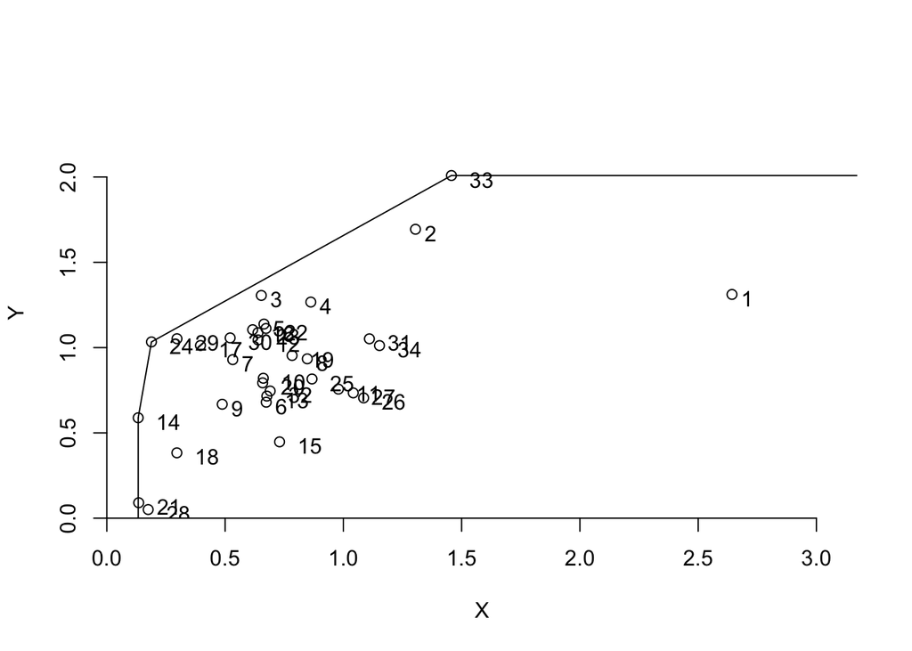

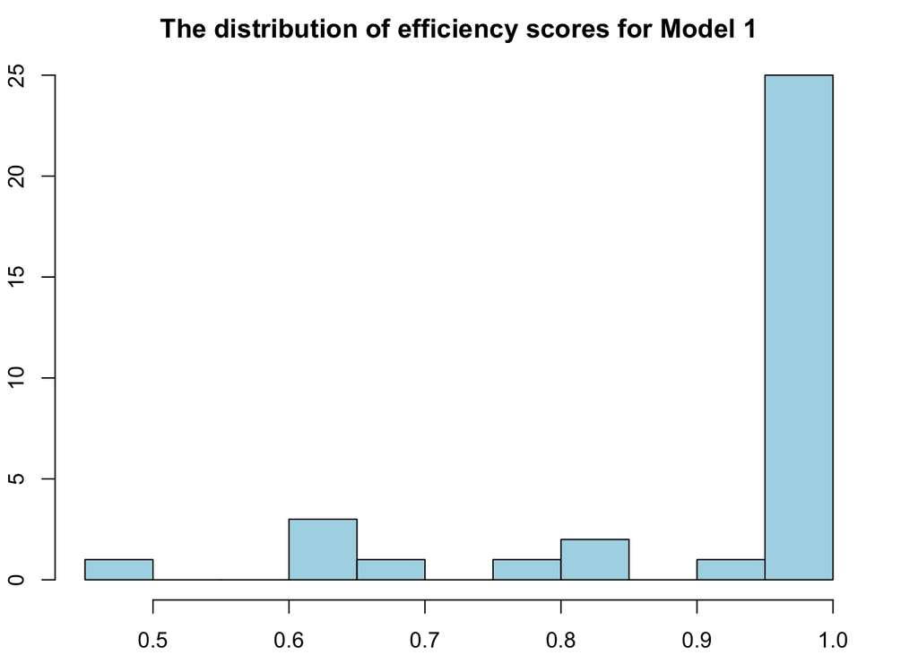

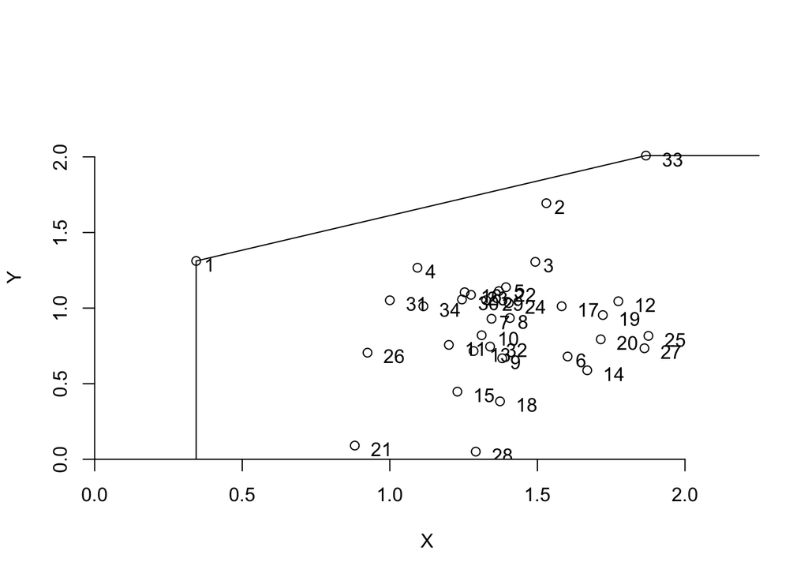

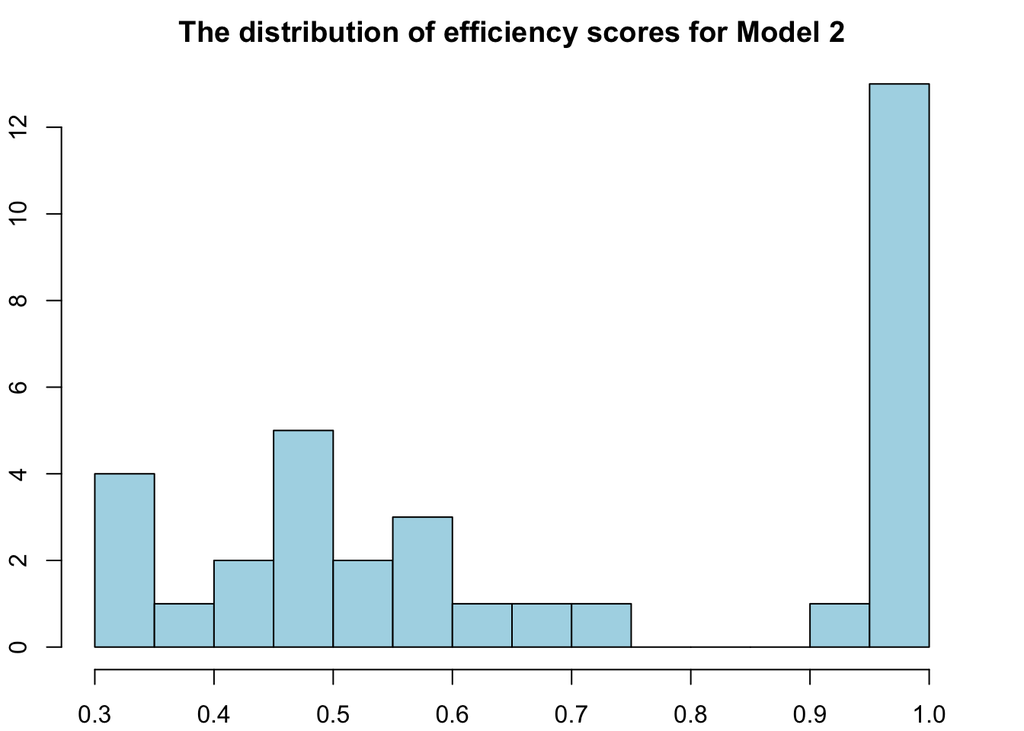

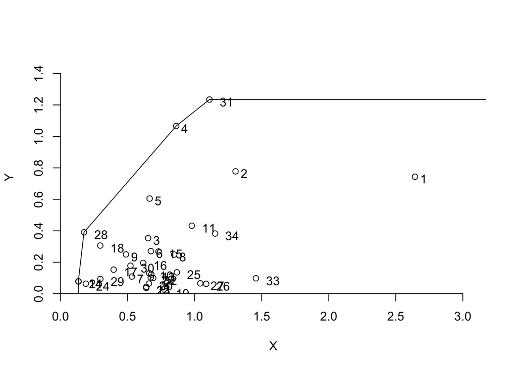

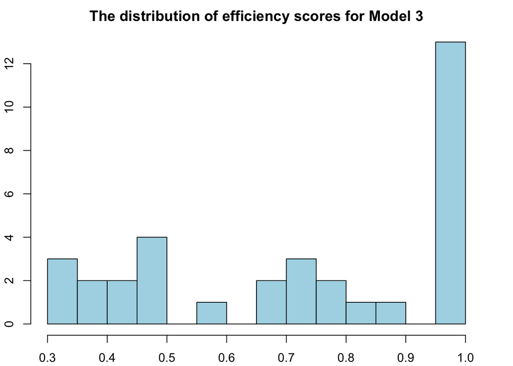

[2 more figures not shown]